# Correspondence Analysis for Student Personalities

Ronny Goei

2023-05-25

# 1 Preface

## 1.1 Pendahuluan

*“EVERYONE DESERVES AN EDUCATION BECAUSE IT IS A HUMAN RIGHT”* adalah kalimat yang tepat untuk menggambarkan bahwa kesetaraan dan kesempatan harus dapat dirasakan oleh seluruh umat manusia tak terkecuali pendidikan, namun, tidak semua berasal dari latar belakang yang sama, disini peran pemerintah sangat penting untuk mengatasi masalah sejak dari hulu (latar belakang ekonomi dan/atau sosial) hingga ke hilir (penyerapan tenaga kerja pada dunia professional).

*Correspondence Analysis* adalah teknik visualisasi data untuk mendapatkan informasi hubungan antara dua atau lebih kategori. Pada kesempatan kali ini, kita akan mencari tahu karakteristik kelulusan pelajar yang melekat ke masing-masing Negara Bagian sehingga dapat ditindaklanjuti dengan tepat.

## 1.2 Library dan Setup

```r
#data cleaning
#data wrangling
library("dplyr")
library("tibble")

#data analysis
library("FactoMineR")
library("factoextra")

#data visualization
library("ggpubr") #untuk balloonplot
library("graphics") #untuk mosaicplot
library("ggplot2")
library("plotly") #interaktif balloon plot

#data reference
library("datasets")
```

## 1.3 Dataset

Pada analisa kali ini, saya menggunakan data dari National Center for Education Statistics (NCES) https://nces.ed.gov/ccd/tables/ACGR_RE_and_characteristics_2019-20.asp yang didalamnya terdapat informasi mengenai persentase siswa SMA di Amerika Serikat yang lulus pada tahun ajaran 2019-2020 dengan detail atribut yang meliputi warna kulit, status ekonomi, kemampuan berbahasa serta yang berkebutuhan khusus.

```r
graduation <- readxl::read_xlsx("data/graduation.xlsx")
graduation
```

| State | Black | White | Economically disadvantaged | English learner | Students with disabilities | Homeless enrolled | Foster care |
| --- | --- | --- | --- | --- | --- | --- | --- |
| Alabama | 88.2 | 92.2 | 85.5 | 72.0 | 68.9 | 74.0 | 67.0 |
| Alaska | 74.0 | 84.4 | 72.3 | 68.0 | 59.0 | 58.0 | 54.0 |
| Arizona | 71.7 | 83.0 | 73.6 | 55.2 | 66.2 | 48.6 | 45.0 |
| Arkansas | 84.5 | 90.9 | 86.2 | 84.4 | 84.1 | 78.0 | 65.0 |
| California | 76.9 | 87.9 | 81.2 | 69.1 | 68.4 | 69.7 | 58.2 |
| Colorado | 76.6 | 86.1 | 72.3 | 70.2 | 61.8 | 56.7 | 31.0 |
| Connecticut | 80.0 | 93.4 | 80.6 | 67.0 | 68.1 | 65.0 | 47.0 |
| Delaware | 87.0 | 90.5 | 82.0 | 76.0 | 73.0 | 73.0 | 74.0 |
| District of Columbia | 72.9 | 93.0 | 62.0 | 56.0 | 56.0 | 55.0 | 53.0 |
| Florida | 86.9 | 91.9 | 87.1 | 85.8 | 82.9 | 80.0 | 57.0 |

[output cut: 19 more lines]

Dengan keterangan sebagai berikut:

- `State` : Negara Bagian
- `Black` dan `White` : skor karakteristik “warna kulit”
- `Economically disadvantaged` : skor karakteristik “Ketidakberuntungan Ekonomi/ Kesulitan Ekonomi”
- `English Learner` : skor karakteristik “Pelajar Bahasa Inggris”
- `Students with disabilities` : skor karakteristik “Pelajar berkebutuhan khusus”
- `Homeless enrolled` : skor karakteristik “Pelajar yang tidak memiliki rumah”
- `Foster care` : skor karakteristik “Pelajar yang berasal dari rumah yatim piatu”

Data tersebut diubah menjadi data table agar dapat digunakan pada fungsi Correspondence Analysis

```r
graduation_table <- graduation %>%
  column_to_rownames(var="State")
graduation_table
```

|  | Black | White | Economically disadvantaged | English learner | Students with disabilities | Homeless enrolled | Foster care |
| --- | --- | --- | --- | --- | --- | --- | --- |
| Alabama | 88.2 | 92.2 | 85.5 | 72.0 | 68.9 | 74.0 | 67.0 |
| Alaska | 74.0 | 84.4 | 72.3 | 68.0 | 59.0 | 58.0 | 54.0 |
| Arizona | 71.7 | 83.0 | 73.6 | 55.2 | 66.2 | 48.6 | 45.0 |
| Arkansas | 84.5 | 90.9 | 86.2 | 84.4 | 84.1 | 78.0 | 65.0 |
| California | 76.9 | 87.9 | 81.2 | 69.1 | 68.4 | 69.7 | 58.2 |
| Colorado | 76.6 | 86.1 | 72.3 | 70.2 | 61.8 | 56.7 | 31.0 |
| Connecticut | 80.0 | 93.4 | 80.6 | 67.0 | 68.1 | 65.0 | 47.0 |
| Delaware | 87.0 | 90.5 | 82.0 | 76.0 | 73.0 | 73.0 | 74.0 |
| District of Columbia | 72.9 | 93.0 | 62.0 | 56.0 | 56.0 | 55.0 | 53.0 |
| Florida | 86.9 | 91.9 | 87.1 | 85.8 | 82.9 | 80.0 | 57.0 |

[output cut: 19 more lines]

# 2 Exploratory Data Analytic (EDA)

```r
summary(graduation_table)
```

```
##      Black           White       Economically disadvantaged English learner
##  Min.   :69.00   Min.   :82.80   Min.   :62.00              Min.   :39.00
##  1st Qu.:75.00   1st Qu.:87.80   1st Qu.:75.90              1st Qu.:65.00
##  Median :78.90   Median :90.30   Median :79.60              Median :69.00
##  Mean   :78.98   Mean   :89.53   Mean   :79.43              Mean   :69.04
##  3rd Qu.:84.50   3rd Qu.:92.20   3rd Qu.:85.00              3rd Qu.:76.00
##  Max.   :88.20   Max.   :95.00   Max.   :89.80              Max.   :89.00
##  Students with disabilities Homeless enrolled  Foster care
##  Min.   :55.40              Min.   :48.60     Min.   :31.00
##  1st Qu.:63.00              1st Qu.:61.00     1st Qu.:50.00
##  Median :68.60              Median :66.00     Median :56.00
##  Mean   :69.95              Mean   :66.62     Mean   :55.39
##  3rd Qu.:75.00              3rd Qu.:74.00     3rd Qu.:62.00
##  Max.   :88.10              Max.   :88.00     Max.   :74.00
```

Nama State (Negara Bagian) sudah kita jadikan index row sehingga summary hanya ditampilkan untuk setiap kolom yang ada pada data yang merupakan atribut karakteristik. Dikarenakan tujuan analisis kali ini adalah ingin mengidentifikasi karakteristik yang melekat pada tiap Negara Bagian, maka nilai statistik yang menarik untuk diperhatikan adalah nilai maksimum.

Insight:

- atribut English Learner memiliki nilai skor maksimum sebesar 89
- atribut Students with disabilities memiliki nilai skor maksimum sebesar 88.10
- atribut Homeless Enrolled memiliki nilai skor maksimum sebesar 88
- atribut Foster Care memiliki nilai skor maksimum sebesar 74

Meskipun fungsi summary memberikan rangkuman data, kita tetap kesulitan untuk menginterpretasikan data. Sehingga kita perlu suatu visualisasi untuk membantu kita menjelaskan data. Dikarenakan data input kita spesial yaitu merupakan tabel kontingensi, maka akan dikenalkan visualisasi khusus untuk tabel kontingensi.

## 2.1 Balloon plot

Balloon plot adalah salah satu jenis plot untuk memvisualisasikan data kategorik yang berukuran besar.

> Fungsi balloon plot adalah membuat tabel grafis dimana setiap sel menampilkan lingkaran berwarna yang ukurannya mencerminkan besar nilainya.

Secara visual, plot ini dapat menghighlight poin data yang nilainya menonjol ditunjukkan semakin besarnya lingkaran, semakin besar ukuran lingkaran maka semakin besar pula nilai datanya.

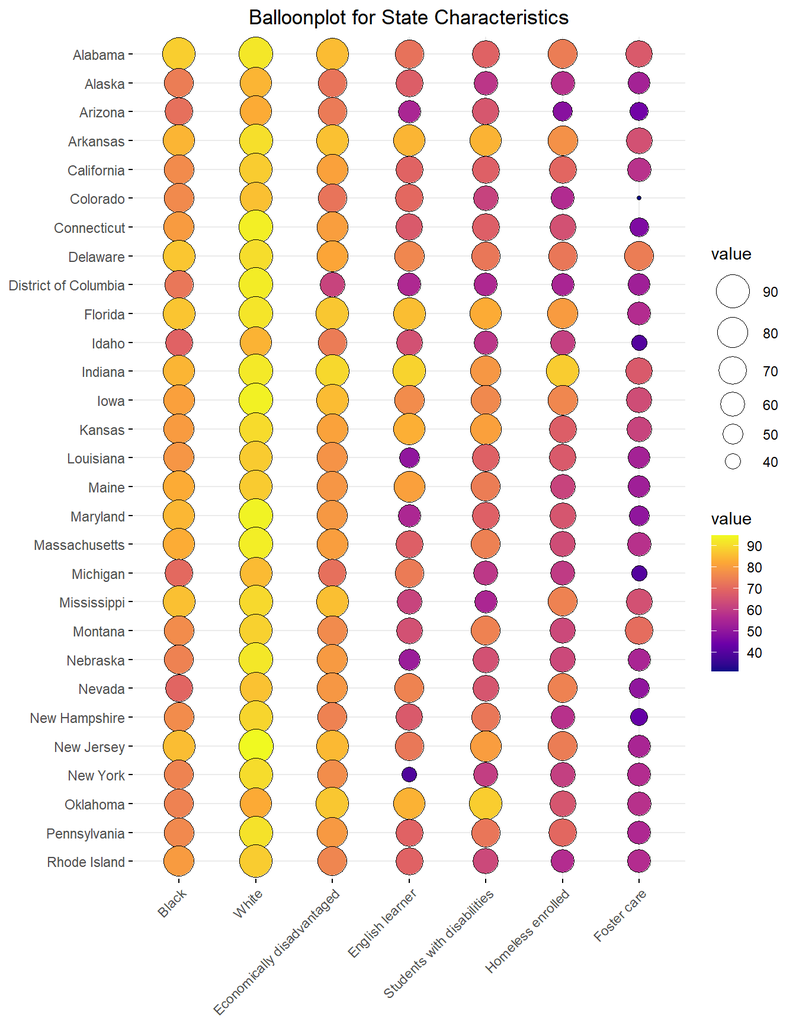

```r
my_cols <- c("#0D0887FF", "#6A00A8FF", "#B12A90FF","#E16462FF", "#FCA636FF", "#F0F921FF")
ggballoonplot(graduation_table, fill = "value") +
  scale_fill_gradientn(colours = my_cols) +
  labs(title = "Balloonplot for State Characteristics") +
  theme(plot.title = element_text(hjust = 0.5))
```

```r
# ggplotly(plot1,height = 1200, width = 800)
```

Plot di atas sudah dimodifikasi agar warna lingkaran juga dapat menunjukkan besarnya nilai, yaitu warna kuning menunjukkan nilai yang semakin besar sementara warna navy menunjukkan nilai semakin kecil. Pada ballon plot di atas, dapat diketahui bahwa terdapat beberapa Negara Bagian dengan nilai frekuensi atribut karakteristik yang tinggi dibanding Negara lainnya. Vice Versa.

Dari balloon plot di atas, kita dapat melihat bahwa:

- Lulusan sedikit lebih didominasi oleh pelajar berkulit putih
- Negara Bagian Colorado, Idaho, Michigan dan New Hampshire relatif menyumbang sangat kecil pelajar yang memiliki karakteristik dari Foster Care
- Negara Bagian New York menyumbang sangat kecil pelajar yang mempelajari Bahasa Inggris
- Negara Bagian Delaware menyumbang keragaman atribut yang cukup seimbang

## 2.2 Mosaic Plot

Mosaic plot digunakan untuk memvisualisasikan tabel kontingensi dan untuk memeriksa hubungan antara variabel kategori. Untuk setiap sel, tinggi batang sebanding dengan frekuensi relatif yang diamati yang dikandungnya:

$$\frac{cell.value}{column.sum}$$

Warna pada plot menunjukkan standardized residuals, yang memberikan intuisi signifikansi hubungan. Standardized residuals adalah akar dari statistik Chi-square yang akan dibahas pada section selanjutnya.

Mosaic plot dapat diinterpresaikan sebagai berikut:

- Sebuah sel diarsir biru jika kita yakin bahwa sel tersebut lebih tinggi dari sel lain dalam baris yang sama
- Sebuah sel diarsir dengan warna merah jika kita yakin bahwa sel tersebut lebih rendah dari sel lain pada baris yang sama

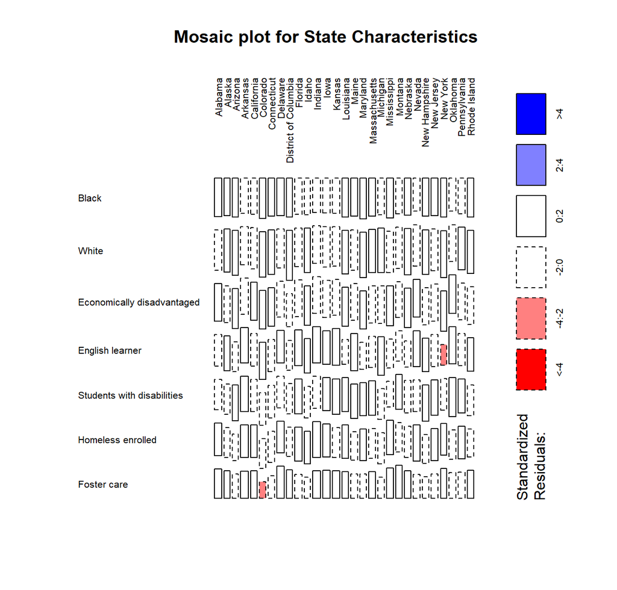

```r
# Mosaic plot of observed values
mosaicplot(graduation_table,
           las = 2,
           shade = T,
           off = 25,
           main = "Mosaic plot for State Characteristics")
```

Dari mosaic plot di atas, kita dapat melihat bahwa:

- Negara Bagian Colorado memiliki kelulusan dari atribut Foster Care yang rendah
- Negara Bagian New York memiliki kelulusan dari atribut English Learner yang rendah
- Sebagian besar Negara Bagian berbagi karakteristik atribut yang serupa

# 3 Correspondence Analysis (CA) Concept

Correspondence Analysis (CA) adalah jenis teknik dimentionality reduction yang dapat digunakan untuk **memvisualisasikan dan mengeksplorasi hubungan variabel kategorikal** dalam sebuah dataset.

Analisis korespondensi (CA) diperlukan untuk tabel kontingensi besar untuk memvisualisasikan titik baris dan titik kolom secara grafis dalam ruang berdimensi dua dimensi.

Plot hasilnya menampilkan:

- hubungan antara kategori baris dan kolom
- setiap titik mewakili kategori
- jarak antara titik mencerminkan kekuatan hubungan antara kategori tersebut

## 3.1 Implementasi CA

```r
graduation.ca <- CA(graduation_table, graph = FALSE)
graduation.ca
```

```
## **Results of the Correspondence Analysis (CA)**
## The row variable has  29  categories; the column variable has 7 categories
## The chi square of independence between the two variables is equal to 102.977 (p-value =  0.9999802 ).
## *The results are available in the following objects:
##
##    name              description
## 1  "$eig"            "eigenvalues"
## 2  "$col"            "results for the columns"
## 3  "$col$coord"      "coord. for the columns"
## 4  "$col$cos2"       "cos2 for the columns"
## 5  "$col$contrib"    "contributions of the columns"
## 6  "$row"            "results for the rows"
## 7  "$row$coord"      "coord. for the rows"
## 8  "$row$cos2"       "cos2 for the rows"
## 9  "$row$contrib"    "contributions of the rows"
## 10 "$call"           "summary called parameters"
## 11 "$call$marge.col" "weights of the columns"
## 12 "$call$marge.row" "weights of the rows"
```

Dalam menginterpretasikan hasil dari analisis korespondensi, terdapat beberapa output yang dihasilkan yaitu statistik Chi-square, nilai Eigen, komponen baris dan komponen kolom. Selanjutnya, akan dibahas satu per satu terkait output ini.

# 4 Chi-Square Test

> Uji chi-square adalah sebuah tes statistik yang membantu kita menentukan apakah ada hubungan yang signifikan antara dua variabel kategorik.

Uji ini sering digunakan dalam social science research, studi medis dan bidang lain di mana kita ingin memeriksa hubungan antara variabel.

Sebagai contoh, misalnya kita ingin mengetahui apakah terdapat hubungan yang signifikan antara usia seseorang dengan tingkat merokok. Kita bisa mengumpulkan data dari sekelompok orang dan menggunakan uji chi-square untuk melihat apakah ada perbedaan yang signifikan kelompok usia tertentu dengan tingkat merokoknya.

Uji hipotesis untuk Chi-Square Test adalah sebagai berikut.

- $H_0$ : Variabel baris dan kolom dari tabel kontingensi adalah independen
- $H_1$ : Variabel baris dan kolom adalah dependen (memiliki hubungan yang signifikan)

Catatan:

- Statistik Chi-square yang dihitung ini dibandingkan dengan nilai kritis (diperoleh dari tabel statistik) dengan derajat kebebasan df = ( r − 1 ) ( c − 1 ) dan alpha = 0,05. r adalah jumlah baris dan c adalah jumlah kolom pada tabel kontingensi.
- Jika statistik Chi-kuadrat yang dihitung lebih besar dari nilai kritis atau **p-value < 0.05**, maka kita dapat menyimpulkan bahwa variabel baris dan kolom tidak independen satu sama lain. Sehingga mereka dikatakan terkait atau **memiliki hubungan secara signifikan**.

Uji hipotesis Chi-Square Test untuk menguji apakah ada perbedaan yang signifikan kelompok usia tertentu dengan tingkat merokoknya.

- $H_0$ : Tidak ada hubungan antara Sebuah Negara Bagian dan atribut personality (independen)
- $H_1$ : Ada hubungan antara sebuah Negara Bagian dan atribut personality

Catatan: H0 ditolak jika pvalue < 0.05

Kesimpulan: p-value > 0.999 , maka H0 kita gagal tolak, artinya tidak ada hubungan antara Negara Bagian dan atribut personality

## 4.1 Nilai Eigen/ Variance

Sama seperti di PCA, eigen atau variance juga menunjukkan banyak informasi yang dipertahankan oleh setiap dimensi. Dimensi 1 menjelaskan variansi terbanyak, diikuti oleh dimensi 2 dan seterusnya. Pada summary `graduation.ca` kita dapat memanggil nilai eigen dengan `$eig`.

```r
graduation.ca$eig
```

```
##         eigenvalue percentage of variance cumulative percentage of variance
## dim 1 0.0030475075              43.678769                          43.67877
## dim 2 0.0019539062              28.004596                          71.68337
## dim 3 0.0009356291              13.410018                          85.09338
## dim 4 0.0006744599               9.666778                          94.76016
## dim 5 0.0002193719               3.144174                          97.90433
## dim 6 0.0001462165               2.095665                         100.00000
```

> Pada data graduation saat menggunakan 2 dimensi, CA berhasil merangkum data kita sebesar 71.68%

## 4.2 Rows Components

Komponen fungsi `graduation.ca$row` berisi:

- `$coord`: koordinat setiap titik baris pada setiap dimensi (1,2,dst). Digunakan untuk membuat plot.
- `$cos2`: kualitas representasi baris.
- `$contrib`: kontribusi baris (dalam %) terhadap definisi dimensi.

### 4.2.1 Rows Coordinat

CA menghasilkan koordinat baru untuk variabel baris pada dimensi baru, yang dapat dipanggil dengan `$coord`.

```r
#Ditampilkan hanya 5 Negara Bagian untuk memperingkas tampilan.
head(graduation.ca$row$coord, 5)
```

```
##                   Dim 1        Dim 2        Dim 3        Dim 4         Dim 5
## Alabama    -0.033380129  0.035487857 -0.023100410 -0.013008876  0.0192904200
## Alaska      0.001180289  0.009298571 -0.011927322 -0.046792397  0.0024739898
## Arizona    -0.017641217 -0.054904027  0.059999546 -0.004905556  0.0147285732
## Arkansas    0.039177234  0.048321216  0.008950018  0.015691435 -0.0004491340
## California -0.006296293  0.020939341 -0.014327178  0.008465513 -0.0007968192
```

Gunakan fungsi `fviz_ca_row()` [in factoextra] untuk memvisualisasikan hanya titik baris:

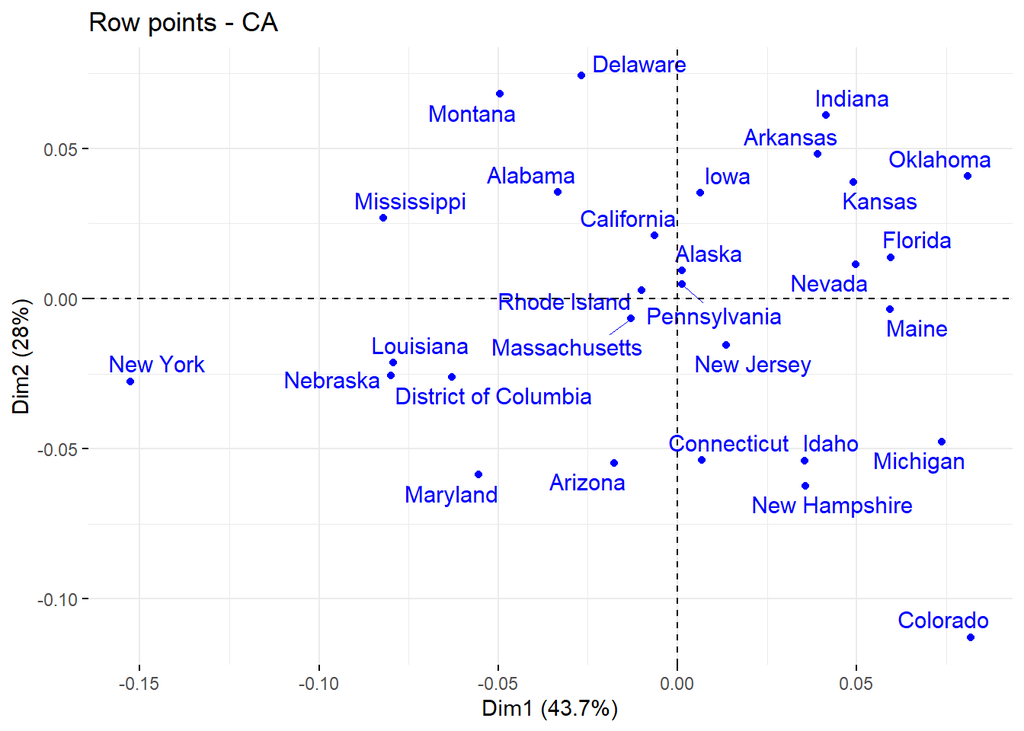

```r
fviz_ca_row(graduation.ca, repel = TRUE)
```

Kita dapat mengidentifikasi kesamaan atau ketidaksamaan dalam kategori baris dengan memperhatikan jarak antar titik koordinat baris.

- Baris dengan profil serupa akan memiliki titik koordinat yang berdekatan (karakteristik mirip)
- Kategori baris yang memiliki hubungan negatif atau bertolak belakang akan memiliki titik koordinat yang berada pada kuadran yang berlawanan (karakteristik tidak mirip)

Sehingga, berdasarkan plot titik koordinat baris insight yang didapatkan adalah:

- Nebraska dan Louisiana, kemudian Idaho dan Newhampshire, memiliki karakteristik atribut personality yang serupa
- Karakteristik pelajar lulusan New York dan Connecticut + New Hampshire tidak serupa padahal negara bagian tersebut bersebelahan secara demografis.

### 4.2.2 Quality of representation of rows

CA dapat merangkum data dan memvisualisasikannya dalam plot dua dimensi. Perhatikan bahwa dua dimensi baru (dimensi 1 & 2) dapat mempertahankan 71.68% dari variasi yang terkandung dalam data. Namun, tidak semua titik data ditampilkan dengan sama baiknya dalam dua dimensi. Kualitas representasi baris pada peta faktor disebut cosinus kuadrat (cos2).
$$cos2 = \frac{row.coord^2}{d^2}$$
dengan row.coord adalah koordinat baris pada sumbu $d^2$ adalah jarak kuadrat dari rata-rata profil baris.

```r
head(graduation.ca$row$cos2)
```

```
##                   Dim 1      Dim 2      Dim 3       Dim 4        Dim 5
## Alabama    0.3208277048 0.36262303 0.15365093 0.048727638 1.071468e-01
## Alaska     0.0005477674 0.03399787 0.05593777 0.860933906 2.406662e-03
## Arizona    0.0413277017 0.40030644 0.47805747 0.003195661 2.880750e-02
## Arkansas   0.3553169804 0.54053539 0.01854369 0.056999851 4.669822e-05
## California 0.0471891564 0.52191335 0.24433953 0.085305878 7.557741e-04
## Colorado   0.3295693941 0.62678571 0.01877245 0.010489489 1.006951e-02
```

Catatan:

- Nilai cos2 adalah 0 sampai 1
- Jika kategori baris terwakili dengan baik oleh dua dimensi, jumlah dari cos2 mendekati 1

Berikut divisualisasikan nilai cos2 untuk masing-masing Negara Bagian. Semakin oranye warna suatu Negara Bagian, semakin bagus kualitas representasi suatu Negara Bagian tersebut pada plot CA.

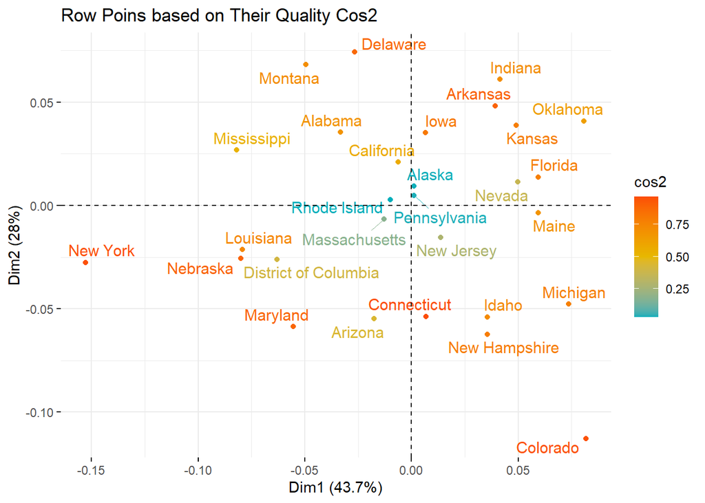

```r
# Color by cos2 values: quality on the factor map
fviz_ca_row(graduation.ca, col.row = "cos2",
             gradient.cols = c("#00AFBB", "#E7B800", "#FC4E07"),
             repel = TRUE,
            title="Row Poins based on Their Quality Cos2")
```

Note: semakin dekat suatu titik koordinat dengan pusat kuadran, biasanya semakin sedikit informasi yang diperoleh. Sehingga umumnya titik koordinat yang jauh dari kuadran yang memiliki banyak insight

### 4.2.3 Contributions of rows to the dimensions

Variabel baris dengan nilai yang lebih besar, berkontribusi paling besar terhadap definisi dimensi. Baris yang paling berkontribusi pada Dim.1 dan Dim.2 adalah yang paling penting dalam menjelaskan variabilitas dalam kumpulan data.

```r
#Pengambilan hanya 5 data teratas hanya untuk kepentingan meringkas tampilan.
head(graduation.ca$row$contrib)
```

```
##                  Dim 1      Dim 2      Dim 3      Dim 4       Dim 5
## Alabama    1.357023946  2.3922806  2.1168588  0.9312786 6.295913228
## Alaska     0.001454745  0.1408262  0.4838792 10.3311634 0.088791155
## Arizona    0.306721525  4.6337934 11.5564424  0.1071648 2.970109247
## Arkansas   1.955633220  4.6401996  0.3324365  1.4175350 0.003570555
## California 0.045073366  0.7775302  0.7601732  0.3681674 0.010028446
## Colorado   6.762571461 20.0597339  1.2546630  0.9725411 2.870365634
```

Besar kontribusi variabel baris pada dimensi 1 dan 2 dapat dilihat dengan visualisasi berikut:

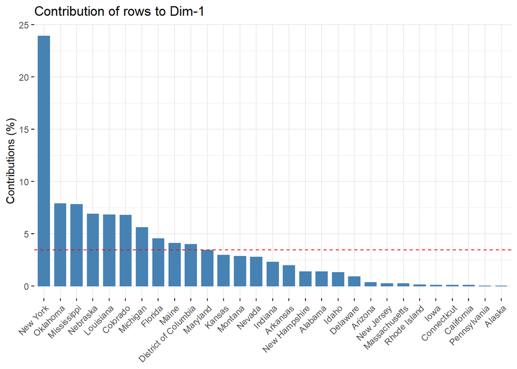

```r
# Contributions of rows to dimension 1
fviz_contrib(graduation.ca, choice = "row", axes = 1)
```

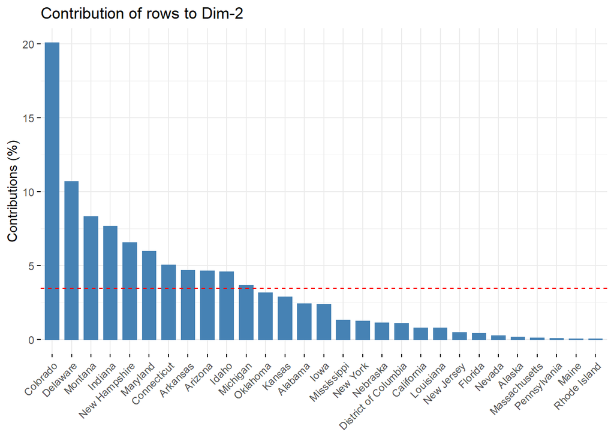

```r
# Contributions of rows to dimension 2
fviz_contrib(graduation.ca, choice = "row", axes = 2)
```

Insight:

- Kategori baris yang paling berkontribusi besar pada dimensi 1 adalah New York
- Kategori baris yang paling berkontribusi besar pada dimensi 2 adalah Colorado

## 4.3 Columns Components

Interpretasi untuk komponen kolom sama persis dengan komponen baris.

Komponen fungsi `graduation-ca$col` berisi:

- `$coord`: koordinat setiap titik kolom pada setiap dimensi (1,2,dst). Digunakan untuk membuat plot.
- `$cos2`: kualitas representasi kolom.
- `$contrib`: kontribusi kolom (dalam %) terhadap definisi dimensi.

```r
# Koordinat kolom
head(graduation.ca$col$coord)
```

```
##                                  Dim 1        Dim 2        Dim 3       Dim 4
## Black                      -0.02694753 -0.031162726 -0.001803787 -0.01846495
## White                      -0.03379917 -0.054668035 -0.001439753 -0.01828960
## Economically disadvantaged -0.01047897 -0.016735097 -0.004384464  0.01904894
## English learner             0.11856755  0.023156333 -0.012581688 -0.02912370
## Students with disabilities  0.03262476  0.001175325  0.061467729  0.03102843
## Homeless enrolled          -0.00239575  0.021551945 -0.053284101  0.03966462
##                                    Dim 5
## Black                       0.0220179065
## White                      -0.0217767766
## Economically disadvantaged  0.0171858717
## English learner            -0.0007318496
## Students with disabilities -0.0053372382
## Homeless enrolled          -0.0086446672
```

```r
# Kualitas representasi tiap kategori kolom pada plot 2 dimensi
head(graduation.ca$col$cos2)
```

```
##                                  Dim 1        Dim 2       Dim 3      Dim 4
## Black                      0.257760741 0.3447067724 0.001154914 0.12102505
## White                      0.230350457 0.6026207115 0.000417978 0.06745053
## Economically disadvantaged 0.070698512 0.1803141191 0.012376740 0.23362267
## English learner            0.900620857 0.0343518285 0.010141172 0.05433799
## Students with disabilities 0.180905188 0.0002347861 0.642171039 0.16363488
## Homeless enrolled          0.001134624 0.0918209917 0.561260307 0.31101093
##                                   Dim 5
## Black                      1.720802e-01
## White                      9.562343e-02
## Economically disadvantaged 1.901588e-01
## English learner            3.431263e-05
## Students with disabilities 4.841607e-03
## Homeless enrolled          1.477289e-02
```

```r
# Kontribusi tiap kategori kolom ke dimensi CA
head(graduation.ca$col$contrib)
```

```
##                                  Dim 1       Dim 2       Dim 3     Dim 4
## Black                       3.69775916  7.71281211  0.05396503  7.844870
## White                       6.59461929 26.90827087  0.03897581  8.725186
## Economically disadvantaged  0.56236030  2.23704747  0.32066510  8.396688
## English learner            62.57900025  3.72286738  2.29517497 17.059991
## Students with disabilities  4.80019745  0.00971676 55.50087665 19.618807
## Homeless enrolled           0.02465356  3.11179228 39.72216486 30.534570
##                                  Dim 5
## Black                      34.29388767
## White                      38.03022162
## Economically disadvantaged 21.01283687
## English learner             0.03312108
## Students with disabilities  1.78468478
## Homeless enrolled           4.45920072
```

Seperti titik baris, titik kolom juga dapat diwarnai berdasarkan kualitas representasinya pada plot CA yang ditunjukkan nilai cos2:

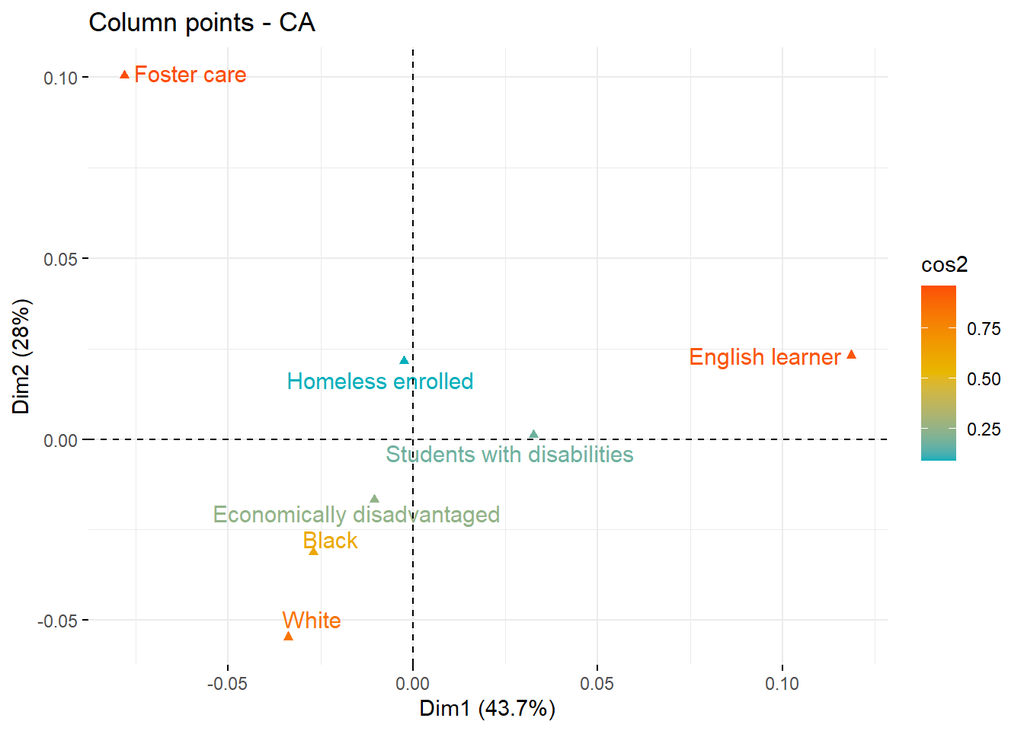

```r
fviz_ca_col(graduation.ca, col.col = "cos2",
             gradient.cols = c("#00AFBB", "#E7B800", "#FC4E07"),
             repel = TRUE)
```

Note: semakin dekat suatu titik koordinat dengan pusat kuadran, biasanya semakin sedikit informasi yang diperoleh. Sehingga umumnya titik koordinat yang jauh dari kuadran yang memiliki banyak insight

Sementara itu, untuk memvisualisasikan kontribusi kolom ke dua dimensi pertama:

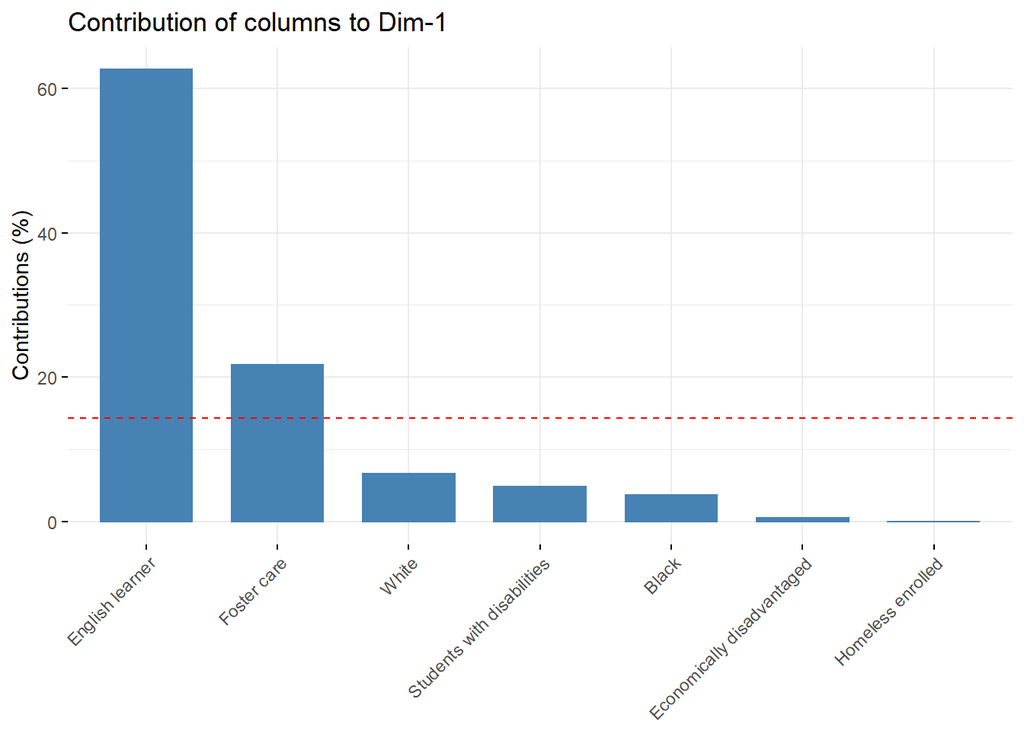

```r
# Contributions of columns to dimension 1
fviz_contrib(graduation.ca, choice = "col", axes = 1)
```

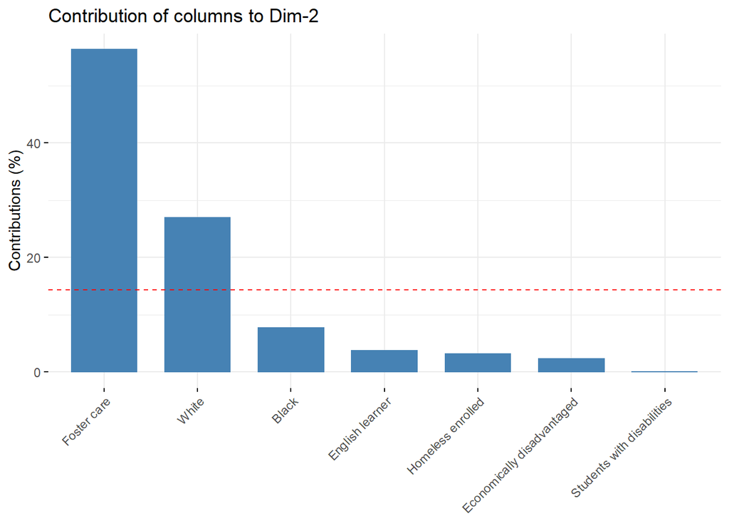

```r
# Contributions of columns to dimension 2
fviz_contrib(graduation.ca, choice = "col", axes = 2)
```

Insight:

- Kategori kolom yang paling berkontribusi besar pada dimensi 1 adalah English Learner
- Kategori kolom yang paling berkontribusi besar pada dimensi 2 adalah Foster Care

# 5 Interpretasi Biplot CA

Plot standar analisis korespondensi adalah biplot simetris di mana baris (titik biru) dan kolom (segitiga merah) direpresentasikan dalam ruang yang sama menggunakan koordinat baru.

Biplot pada CA artinya gabungan dua plot, yaitu **plot untuk variabel baris** dan **plot untuk variabel kolom**. Koordinat pada biplot CA mewakili profil baris dan kolom. Biplot CA di R dapat diperoleh menggunakan fungsi `fviz_ca_biplot(ca objek, repel = TRUE)`

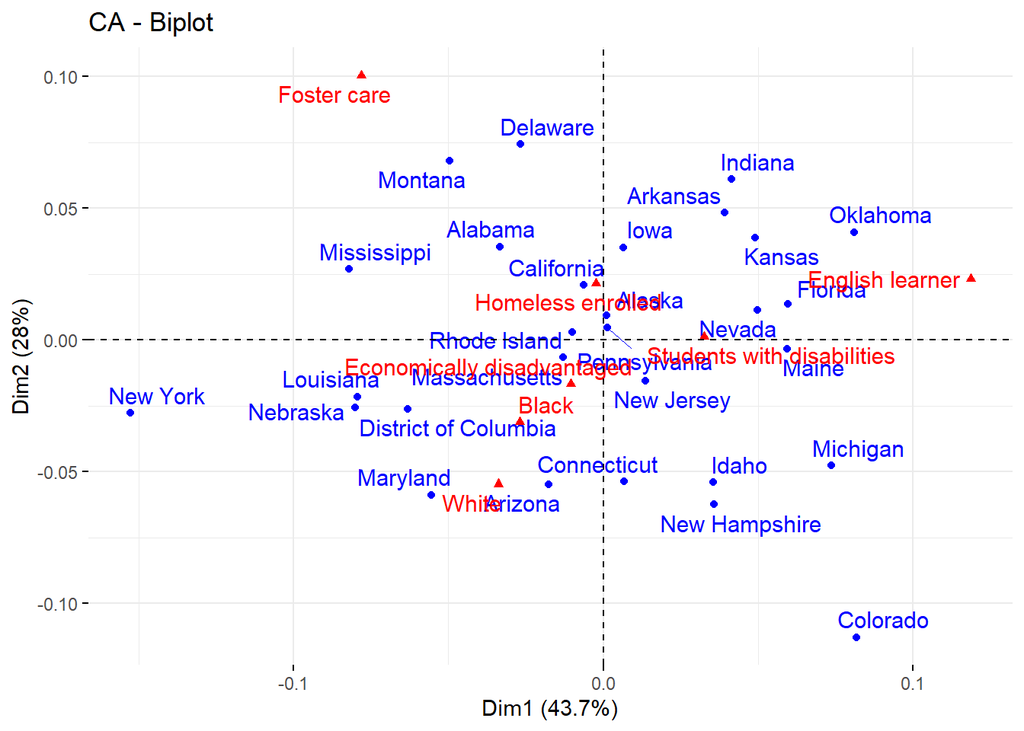

```r
fviz_ca_biplot(graduation.ca, repel = TRUE)
```

Berikut adalah beberapa poin yang perlu diperhatikan dalam menginterpretasi biplot CA:

- Kedekatan titik kategori dengan titik asal menunjukkan **kekhasan kategori** tersebut
  - Jika titik kategori terletak dekat dengan titik asal plot menunjukkan bahwa kategori tersebut kurang berbeda dari kategori lainnya atau kurang khas
  - Semakin jauh suatu kategori dari titik asalnya, semakin diskriminatif kategori tersebut, yang menunjukkan bahwa kategori tersebut memiliki karakteristik khas yang membedakannya dari kategori lain
- Kedekatan suatu titik dengan titik lainnya dalam konteks baris atau kolom menunjukkan kesamaan profil/karakteristik **(similarity)**, jika data discaling dengan benar. Namun fungsi `CA()` sudah secara otomatis melakukan scaling.
- Untuk mengetahui **hubungan dari kategori baris dan kategori kolom** dilihat dari seberapa besar sudut yang terbentuk dari panah baris dan kolom ke titik asalnya. Tambahkan parameter `arrow` untuk menampilkan panah baris dan kolom pada biplot.

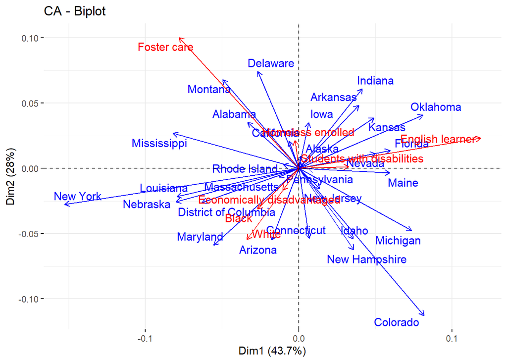

```r
fviz_ca_biplot(graduation.ca, repel = TRUE, arrows = c(TRUE, TRUE))
```

Cara interpretasi hubungan dari kategori baris dan kategori kolom:

- sudut panah baris (biru) dan panah kolom (merah) mendekati 0: kategori baris dan kolom memiliki hubungan positif
- sudut 90 derajat: kategori baris dan kolom tidak memiliki hubungan
- sudut 180 derajat: kategori baris dan kolom memiliki hubungan negatif
- Semakin jauh suatu titik dari titik asalnya, semakin kuat hubungannya dengan suatu kategori lain sesuai kriteria sudutnya (positif/negatif)

Dengan demikian, berdasarkan profil baris (personality), berikut adalah pemetaan untuk data State and Personality:

- Pada Negara Bagian Florida banyak yang memiliki lulusan English Learner
- Pada Negara Bagian Nevada dan Maine banyak yang memiliki lulusan dengan Disability
- Lulusan kulit putih dan kulit hitam tercampur hampir merata dengan Negara Bagian yang paling berpengaruh yaitu Negara Bagian Maryland, Arizona dan Connecticut.

# 6 Kesimpulan

Correspondence Analysis memberikan hasil visualisasi yang mudah diinterpretasi sehingga kita dengan mudah menemukan asosiasi dari dua kategori variabel. CA dapat membantu kita mendefinisikan atribut karakteristik (variabel kolom) dari suatu Negara Bagian (variabel baris) serta mempetakannya sesuai dengan masing-masing Negara Bagian. Jika dibandingkan dengan ballon plot dan mosaicplot, ada beberapa hasil pemetaan yang sama. Namun, CA memberikan hasil pemetaan yang lebih kuat dengan memvisualisasikan hubungan kedua variabel pada biplot.

Setelah mengetahui pemetaan atribut karakteristik untuk masing-masing Negara Bagian, pemerintah negara setempat dapat menyesuaikan kebijakan untuk masyarakatnya diantaranya :

1. Membantu pengadaan tempat tinggal (untuk mengatasi Homeless) atau membuka lapangan kerja sehingga mereka dapat menyewa/ membeli rumah,
2. Mengurangi angka disabilitas dengan meningkatkan standard kualitas hidup(untuk mengatasi Students with Disabilities) semisal gizi yang baik dan penyuluhan akan pentingnya gizi seimbang untuk tumbuh kembang anak,
3. Memperbaiki ekonomi negara secara keseluruhan(untuk mengatasi Economy Disadvantage),
4. Memperbaiki kualitas hidup keluarga (untuk mengatasi Foster Care).

# 7 Referensi

- [How to create contingency table](https://sphweb.bumc.bu.edu/otlt/MPH-Modules/PH717-QuantCore/PH717-Module3-Frequency-Association/PH717-Module3-Frequency-Association14.html)
- [Correspondence Analysis Paper](https://www.sciencedirect.com/topics/earth-and-planetary-sciences/correspondence-analysis)
- [Correspondence Analysis for Brand Personalities Paper](https://journals.sagepub.com/doi/10.1177/1470785318801480)
- [3D Correspondence Analysis with plotly](https://www.displayr.com/3d-correspondence-analysis-plots-in-r-using-plotly/)
- [Adding Outliers as Supplementary Elements to a Correspondence Analysis](http://www.sthda.com/english/articles/31-principal-component-methods-in-r-practical-guide/113-ca-correspondence-analysis-in-r-essentials/)
- [Multiple Correspondence Analysis (MCA)](http://www.sthda.com/english/articles/31-principal-component-methods-in-r-practical-guide/114-mca-multiple-correspondence-analysis-in-r-essentials/)